# PeMS Freeway Speed and CHP Reported Starts

This example prepares hourly freeway speed in miles per hour for the Los Angeles and San Francisco Bay areas. The drawing input covers all 24 source hours of 16 June 2026. By default, the report shows the 08:00 hour for both regions. Diamonds mark when the California Highway Patrol (CHP) logged the start of an incident.

## 1 Set up the example

In an interactive R session, set the working directory to the folder containing this report and run the visible R blocks in order. The blocks use the installed `bdynets` package, the supplied PeMS and CHP files, and a temporary directory for the prepared tables. The YAML parameters control the plotted hour, offline street context and export.

`prepare.R` contains this case’s conversion functions.

The expandable code blocks in the following steps show the definitions from the same scripts used by this report. The regular R blocks load those scripts, call the functions in order and show the resulting data. The detector and event readers are in `scripts/read-source.R`. The local `scripts/prepare-input.R` aligns the road and time tables and writes the prepared RDS files. `scripts/street-context.R` reads the local background, and `scripts/report-export.R` saves the prepared data and static maps when export is requested.

```r
library(bdynets)
source("scripts/prepare-input.R", local = TRUE)
source("prepare.R", local = TRUE)
source("scripts/report-export.R", local = TRUE)
source("scripts/street-context.R", local = TRUE)
if (!exists("params", inherits = FALSE)) {
  params <- rmarkdown::yaml_front_matter("pems-speed-report.Rmd")$params
}
data_dir <- "data"
work <- tempfile("pems-speed-report-")
dir.create(work)
```

The prepared input guide describes the final drawing object. For other source data, choose the fields, time intervals and conversion rules that fit that data.

## 2 Read the supplied data

The supplied files include Caltrans Station 5-Minute records from districts 04, 07, 08 and 12, dated D04 station metadata, and June CHP incident summaries and details. The bundled detector text preserves all 52 source columns in the selected rows for 16 June. The supplied CHP summaries contain starts on 16 June from the four districts, even though the source filename contains `month`. The detail file contains messages linked to those IDs, including messages posted after midnight. Preparation applies the two regional bounds to the supplied event coordinates.

The project reference files define the study roads and identify the detector positions used by the published series. The June speed manifest identifies active LA positions. The speed HTML maps each position to a detector ID, and the earlier LA speed HTML identifies stations eligible for the legacy speed series. The source manifest records both names. Use the **Path in this example** column below to locate the files supplied with the example. **Upstream file** identifies the original source.

```r
register_file <- file.path(data_dir, "case-register.rds")
raw <- file.path(data_dir, "raw")
files <- pems_files(file.path(raw, "caltrans"), file.path(raw, "reference"))
source_manifest <- read.csv(file.path(raw, "source-manifest.csv"))
source_manifest <- source_manifest[match(names(files), source_manifest$role), ]
knitr::kable(data.frame(
  role = source_manifest$role,
  bundled_path = file.path(raw, source_manifest$file),
  upstream_file = source_manifest$source_file
), col.names = c("Role", "Path in this example", "Upstream file"), row.names = FALSE)
```

| Role | Path in this example | Upstream file |
| --- | --- | --- |
| detector04 | data/raw/caltrans/5min/D04/2026/2026_06/d04_text_station_5min_2026_06_16.txt | d04_text_station_5min_2026_06_16.txt.gz |
| detector07 | data/raw/caltrans/5min/D07/2026/2026_06/d07_text_station_5min_2026_06_16.txt | d07_text_station_5min_2026_06_16.txt.gz |
| detector08 | data/raw/caltrans/5min/D08/2026/2026_06/d08_text_station_5min_2026_06_16.txt | d08_text_station_5min_2026_06_16.txt.gz |
| detector12 | data/raw/caltrans/5min/D12/2026/2026_06/d12_text_station_5min_2026_06_16.txt | d12_text_station_5min_2026_06_16.txt.gz |
| metadata | data/raw/caltrans/metadata/D04/d04_text_meta_2026_04_08.txt | d04_text_meta_2026_04_08.txt.gz |
| incidents | data/raw/caltrans/chp/2026/2026_06/all_text_chp_incidents_month_2026_06.txt | all_text_chp_incidents_month_2026_06.txt.gz |
| details | data/raw/caltrans/chp/2026/2026_06/all_text_chp_incident_det_month_2026_06.txt | all_text_chp_incident_det_month_2026_06.txt.gz |
| station_map | data/raw/reference/processing_runtime/clean_data_update/mapping_cache/2026-06_d04/station_maps/snapshot_d04_2026-04-08.csv | snapshot_d04_2026-04-08.csv |
| flow_geometry | data/raw/reference/PeMS_2020_2026_maps/map/la_area_freeway_volume_2020_01_to_2026_06.html | la_area_freeway_volume_2020_01_to_2026_06.html |
| annotations | data/raw/reference/CHP_full_English_2026_10_21/all_months/.work/2026-06/events.csv | events.csv |
| speed_manifest | data/raw/reference/PeMS_2020_2026_maps/map/data/speed/manifest.json | manifest.json |
| speed_geometry | data/raw/reference/PeMS_2020_2026_maps/map/la_area_freeway_speeds_2020_01_to_2026_06.html | la_area_freeway_speeds_2020_01_to_2026_06.html |
| legacy_geometry | data/raw/reference/PeMS_2years/map/la_area_freeway_speeds_2024_07_to_2026_06.html | la_area_freeway_speeds_2024_07_to_2026_06.html |

### 2.1 Inspect the case register and station links

The supplied case register preserves the link selections and travel-order decisions for the 16 June 2026 case from the 21 November handover. This register is a supplied case reference created before the report runs. The report reads the recorded choices from it. For another date or study area, choose the links, event scope and frame starts for that dataset during preparation. The input inventory lists the other references. The register stores the LA links whose endpoint order and geometry need to be reversed together, the selected D04 directed endpoint pairs, the event coordinate bounds and category lookup, and the 24 hour starts.

LA road geometry comes from the project volume HTML configuration. D04 road geometry connects the two endpoint coordinates from the dated Caltrans metadata, with the two detectors on the same freeway and direction. The D04 station-map CSV identifies the stations selected for the Bay Area. Match its `station_id` and the register’s endpoint IDs to `ID` in the station metadata.

**Code that reads the register, maps positions to sensors and builds the directed roads**

```r
pems_case_times <- function(times) {
  midnight <- as.numeric(as.POSIXct("2026-06-16", tz = "UTC"))
  if (!is.numeric(times) || !identical(as.numeric(times), midnight + (0:23) * 3600)) {
    stop("The PeMS case requires all 24 consecutive source-hour starts on 2026-06-16.")
  }
}

pems_map_config <- function(file) {
  literal <- grep("^const config = ", readLines(file, warn = FALSE), value = TRUE)
  if (length(literal) != 1L) stop("Expected one source-map configuration in ", basename(file))
  jsonlite::fromJSON(sub(";[[:space:]]*$", "", sub("^const config = ", "", literal)))
}

pems_positions <- function(manifest, config, month_key) {
  months <- jsonlite::read_json(manifest, simplifyVector = FALSE)
  month <- Filter(function(x) identical(x$key, month_key), months)
  if (length(month) != 1L) stop("Expected one manifest entry for ", month_key)
  positions <- month[[1L]][["segmentPositions"]]
  stations <- config[["positionStations"]]
  valid_position <- function(index) {
    is.numeric(index) && length(index) == 1L && is.finite(index) && index == trunc(index) &&
      index >= 0 && index < length(stations)
  }
  if (!is.list(positions) || !is.null(names(positions)) || !length(positions) ||
      !all(vapply(positions, valid_position, logical(1L)))) {
    stop("Active positions and station mapping disagree.")
  }
  positions <- unlist(positions, use.names = FALSE)
  selected <- stations[positions + 1L]
  valid_station <- function(id) {
    (is.character(id) || is.numeric(id)) && length(id) == 1L && !is.na(id) && grepl("^[0-9]+$", id)
  }
  if (anyDuplicated(positions) || !all(vapply(selected, valid_station, logical(1L)))) {
    stop("Active positions and station mapping disagree.")
  }
  data.frame(segment_position = positions,
    station_id = vapply(selected, as.character, character(1L), USE.NAMES = FALSE))
}

pems_case_roads <- function(register, config, meta) {
  la <- config$links
  reverse <- la$id %in% register$la_reverse_id
  if (anyDuplicated(la$id) || any(!register$la_reverse_id %in% la$id)) {
    stop("LA display IDs differ from the direction register.")
  }
  la$geometry <- lapply(seq_len(nrow(la)), function(i) {
    geometry <- la$coords[[i]][, 2:1, drop = FALSE]
    if (reverse[i]) geometry[nrow(geometry):1, , drop = FALSE] else geometry
  })
  la$coords <- NULL
  for (key in c("station", "abs_pm", "station_index")) {
    from <- paste0("from_", key)
    to <- paste0("to_", key)
    saved <- la[[from]][reverse]
    la[[from]][reverse] <- la[[to]][reverse]
    la[[to]][reverse] <- saved
  }
  la$region <- "Los Angeles Area"
  la$road_id <- as.character(la$id)

  keys <- register$d04_links
  from <- meta[match(keys$from_station, meta$ID), ]
  to <- meta[match(keys$to_station, meta$ID), ]
  if (anyNA(from$ID) || anyNA(to$ID) ||
      any(from$Fwy != to$Fwy | from$Dir != to$Dir | from$District != "4" |
          to$District != "4" | from$Type != "ML" | to$Type != "ML")) {
    stop("D04 link endpoints do not agree with station metadata.")
  }
  bay <- data.frame(district = "04", freeway = from$Fwy, direction = from$Dir,
    from_station = from$ID, to_station = to$ID, from_abs_pm = as.numeric(from$Abs_PM),
    to_abs_pm = as.numeric(to$Abs_PM), id = seq_len(nrow(keys)) - 1L,
    from_station_index = NA_integer_, to_station_index = NA_integer_,
    region = "San Francisco Bay Area", road_id = keys$road_id)
  bay$geometry <- lapply(seq_len(nrow(keys)), function(i) {
    cbind(as.numeric(c(from$Longitude[i], to$Longitude[i])),
      as.numeric(c(from$Latitude[i], to$Latitude[i])))
  })
  rbind(la[names(bay)], bay)
}

pems_selection <- function(register_file, files) {
  register <- readRDS(register_file)
  if (!identical(register$schema, "pems-links-and-rules-v1")) {
    stop("The selected display links need a compatible endpoint register.")
  }
  pems_case_times(register$settings$times)
  month <- format(as.POSIXct(register$settings$times[1L], origin = "1970-01-01", tz = "UTC"),
    "%Y_%m", tz = "UTC")
  # The original volume map holds the shared LA link geometry.
  config <- pems_map_config(files["flow_geometry"])
  metadata <- read.delim(files["metadata"], colClasses = "character", quote = "",
    na.strings = NULL, check.names = FALSE, fileEncoding = "latin1")
  if (anyDuplicated(metadata$ID)) stop("Metadata station IDs are duplicated.")
  result <- list(register = register, config = config, metadata = metadata)
  result$speed <- pems_positions(files["speed_manifest"], pems_map_config(files["speed_geometry"]), month)
  legacy <- pems_map_config(files["legacy_geometry"])$stations
  legacy_ids <- sub("\\.0$", "", as.character(legacy$station[!is.na(legacy$speed_index)]))
  result$speed$in_legacy <- result$speed$station_id %in% legacy_ids
  result
}
```

```r
selection <- pems_selection(register_file, files)
register <- selection$register
frame_times <- register$settings$times
register$origin["projection"]
```

```
## $projection
## [1] "Link-selection and travel-order decisions from the published 16 June 2026 case; geographic selection, category lookup and case settings."
```

```r
data.frame(la_reversed_links = length(register$la_reverse_id),
           bay_directed_links = nrow(register$d04_links),
           event_type_mappings = nrow(register$event_categories),
           hour_starts = length(frame_times))
```

```
##   la_reversed_links bay_directed_links event_type_mappings hour_starts
## 1              2227               2203                  52          24
```

```r
knitr::kable(register$scopes, row.names = FALSE, digits = 3L)
```

| region | south | west | north | east |
| --- | --- | --- | --- | --- |
| Los Angeles Area | 33.375 | -119.234 | 35.633 | -114.530 |
| San Francisco Bay Area | 36.919 | -123.030 | 38.850 | -121.381 |

```r
knitr::kable(head(register$d04_links, 3L), row.names = FALSE)
```

| road_id | from_station | to_station |
| --- | --- | --- |
| D04:101:N:400001:404753 | 400001 | 404753 |
| D04:101:N:400007:400817 | 400007 | 400817 |
| D04:101:N:400010:400473 | 400010 | 400473 |

```r
station_map <- read.csv(files[["station_map"]], colClasses = "character")
bay_pair <- as.character(unlist(register$d04_links[1L, c("from_station", "to_station")]))
station_ref <- selection$metadata[match(bay_pair, selection$metadata$ID),
                                  c("ID", "Fwy", "Dir", "Latitude", "Longitude")]
station_ref$segment_id <- station_map$segment_id[match(station_ref$ID, station_map$station_id)]
knitr::kable(station_ref, row.names = FALSE)
```

| ID | Fwy | Dir | Latitude | Longitude | segment_id |
| --- | --- | --- | --- | --- | --- |
| 400001 | 101 | N | 37.364085 | -121.901149 | 5504 |
| 404753 | 101 | N | 37.364689 | -121.902989 | 8008 |

```r
knitr::kable(head(selection$speed, 3L), row.names = FALSE)
```

| segment_position | station_id | in_legacy |
| --- | --- | --- |
| 0 | 1201054 | TRUE |
| 1 | 1201066 | TRUE |
| 2 | 1201076 | TRUE |

The June key selects active zero-based positions from the speed manifest. `positionStations[position + 1]` in the speed HTML configuration supplies the detector IDs. The earlier speed HTML supplies the eligible detector IDs from its `stations` entries with a `speed_index`. The volume HTML supplies the shared LA link geometry. The selected positions and D04 station IDs determine which measurements enter the native matrices.

### 2.2 Read the source day and link the records

The detector reader retains the freeway mainline records for this case. The detector fields used here are `V1` for the source clock, `V2` for the detector ID, `V3` for the district and `V12` for five-minute average speed in mph. Preparation checks that each daily timestamp belongs to one of the 288 five-minute slots on the case day. The numeric time keys encode the source clock, whose UTC offset is unspecified.

CHP summary fields 1 and 4 give the incident ID and start time, fields 10 and 11 give latitude and longitude, and field 12 gives the district. Preparation matches detail rows to summary IDs and counts the messages. For included LA starts it joins the supplied English `events.csv` by incident ID and checks its message count before using the English summary. Bay Area descriptions use the original summary fields. Coordinates put each start in one of three groups in the native table. Only starts marked `inside` enter the prepared event table; `outside` means valid coordinates outside the region, and `invalid` means bad coordinates.

**Code that reads detector records and places them in station-by-time slots**

```r
pems_detector_rows <- function(file, district, labels) {
  columns <- rep("NULL", 52L)
  columns[c(1L, 2L, 3L, 6L)] <- c("character", "character", "integer", "character")
  columns[12L] <- "numeric"
  rows <- read.csv(file, header = FALSE, colClasses = columns, quote = "")
  if (any(!rows$V1 %in% labels)) {
    stop("Invalid daily five-minute source-clock timestamp in ", basename(file), ".")
  }
  if (anyNA(rows$V3) || any(rows$V3 != district)) {
    stop("The supplied detector text contains records from a different district: ", basename(file))
  }
  mainline <- rows[rows$V6 %in% "ML", , drop = FALSE]
  mainline
}

pems_five_minute_clock <- function(times) {
  rep(times, each = 12L) + rep(seq(0, 3300, 300), length(times))
}

pems_observations <- function(files, times) {
  pems_case_times(times)
  clock <- pems_five_minute_clock(times)
  labels <- format(as.POSIXct(clock, origin = "1970-01-01", tz = "UTC"), "%m/%d/%Y %H:%M:%S")
  districts <- c(4L, 7L, 8L, 12L)
  detector_names <- paste0("detector", sprintf("%02d", districts))
  records <- Map(pems_detector_rows, unname(files[detector_names]), districts,
    MoreArgs = list(labels = labels))
  names(records) <- detector_names
  columns <- rep("NULL", 20L)
  columns[c(1L, 4:7, 10:12)] <- "character"
  incidents <- read.csv(files["incidents"], header = FALSE, colClasses = columns, na.strings = NULL)
  starts <- as.numeric(pems_chp_clock(incidents$V4))
  if (any(starts < times[1L] | starts >= times[1L] + 86400)) {
    stop("CHP summary starts must all be on the supplied day.")
  }
  if (any(!incidents$V12 %in% c("4", "7", "8", "12"))) {
    stop("CHP summaries must belong to districts 04, 07, 08 or 12.")
  }
  list(clock = clock, labels = labels, records = records, incidents = incidents)
}

pems_la_station_slots <- function(observations, stations, field) {
  rows <- do.call(rbind, observations$records[c("detector07", "detector08", "detector12")])
  rows <- rows[rows$V2 %in% stations, , drop = FALSE]
  row <- match(rows$V1, observations$labels)
  column <- match(rows$V2, stations)
  slots <- length(observations$clock)
  cell <- row + (column - 1L) * slots
  if (anyNA(cell)) stop("Unknown LA detector or five-minute slot.")
  if (anyDuplicated(cell)) stop("Duplicate LA detector and five-minute slot.")
  values <- matrix(NA_real_, slots, length(stations))
  values[cell] <- rows[[field]]
  values
}

pems_d04_selection <- function(meta, station_map_file) {
  ids <- sort(meta$ID[meta$District == "4" & meta$Type == "ML"])
  station_map <- read.csv(station_map_file, colClasses = "character")
  mapped <- station_map[["station_id"]]
  if (!length(mapped) || anyDuplicated(mapped) || any(!mapped %in% ids)) {
    stop("D04 station mapping does not align with ML metadata.")
  }
  list(station_id = ids, matched_station_id = ids[ids %in% mapped])
}

pems_station_slots <- function(stations, clocks, values, station_ids, labels) {
  if (!length(station_ids) || anyNA(station_ids) || anyDuplicated(station_ids) ||
      !length(labels) || anyNA(labels) || anyDuplicated(labels)) {
    stop("Declare unique stations and source-clock slots.")
  }
  row <- match(as.character(stations), station_ids)
  column <- match(as.character(clocks), labels)
  if (anyNA(row) || anyNA(column)) stop("An unexpected source station or timestamp is present.")
  cell <- row + (column - 1L) * length(station_ids)
  if (anyDuplicated(cell)) stop("Duplicate station and timestamp.")
  if (length(cell) != length(station_ids) * length(labels)) {
    stop("Missing station and timestamp in D04 detector records.")
  }
  result <- matrix(NA_real_, length(station_ids), length(labels), dimnames = list(station_ids, labels))
  result[cell] <- values
  result
}

pems_d04_station_rows <- function(d04, values, times) {
  if (!is.matrix(values) || !is.numeric(values) ||
      anyNA(d04$station_id) || anyDuplicated(d04$station_id) ||
      anyNA(d04$matched_station_id) || anyDuplicated(d04$matched_station_id) ||
      !identical(rownames(values), d04$station_id) ||
      ncol(values) != 12L * length(times) ||
      !identical(as.numeric(d04$minute), pems_five_minute_clock(times) %% 86400 / 60)) {
    stop("D04 source minutes and output hours do not align.")
  }
  row <- match(d04$matched_station_id, d04$station_id)
  if (anyNA(row)) stop("A matched D04 station is absent from its source observations.")
  row
}

pems_native <- function(stages, observations, files) {
  register <- stages$register
  roads <- pems_case_roads(register, stages$config, stages$metadata)
  incidents <- pems_incidents(observations$incidents, files, register$scopes)
  la <- pems_la_speed(stages$speed, observations)
  d04 <- pems_d04_speed(observations, stages$metadata, files["station_map"])
  list(schema = "pems-speed-source-v1", roads = roads, la = la, d04 = d04,
    event_summaries = incidents$summaries, event_categories = register$event_categories,
    scopes = register$scopes, settings = register$settings, register_origin = register$origin,
    source_files = data.frame(file = basename(files), bytes = unname(file.info(files)$size),
      role = names(files), row.names = NULL), incident_details = incidents$details)
}
```

**Code that reads incident starts, assigns coordinates and applies the geographic scope**

```r
pems_event_scope <- function(events, scopes) {
  regions <- c("Los Angeles Area", "San Francisco Bay Area")
  bounds <- c("west", "east", "south", "north")
  if (!is.data.frame(scopes) || !all(c("region", bounds) %in% names(scopes)) ||
      nrow(scopes) != length(regions) || !setequal(scopes$region, regions) ||
      !all(vapply(scopes[bounds], is.numeric, logical(1L))) ||
      any(!is.finite(as.matrix(scopes[bounds]))) ||
      any(scopes$west < -180 | scopes$east > 180 | scopes$west >= scopes$east |
          scopes$south < -90 | scopes$north > 90 | scopes$south >= scopes$north)) {
    stop("Each PeMS region needs one set of finite regional bounds in longitude and latitude.")
  }
  if (any(!events$district %in% c("04", "07", "08", "12"))) {
    stop("An incident district has no declared regional scope.")
  }
  region <- ifelse(events$district == "04", regions[2L], regions[1L])
  at <- match(region, scopes$region)
  longitude <- suppressWarnings(as.numeric(events$lon))
  latitude <- suppressWarnings(as.numeric(events$lat))
  valid <- is.finite(longitude) & is.finite(latitude) & abs(longitude) <= 180 & abs(latitude) <= 90
  inside <- valid & longitude >= scopes$west[at] & longitude <= scopes$east[at] &
    latitude >= scopes$south[at] & latitude <= scopes$north[at]
  list(inside = inside, outside = valid & !inside, invalid = !valid)
}

pems_scope_class <- function(events, scopes) {
  scope <- pems_event_scope(events, scopes)
  ifelse(scope$inside, "inside", ifelse(scope$invalid, "invalid", "outside"))
}

pems_chp_clock <- function(values) {
  text <- as.character(values)
  source_format <- "%m/%d/%Y %H:%M:%S"
  if (anyNA(text) || any(!grepl("^[0-9]{2}/[0-9]{2}/[0-9]{4} [0-9]{2}:[0-9]{2}:[0-9]{2}$", text))) {
    stop("CHP start times must use the complete source clock.")
  }
  clock <- as.POSIXct(strptime(text, source_format, tz = "UTC"))
  if (anyNA(clock) || any(format(clock, source_format, tz = "UTC") != text)) {
    stop("Invalid CHP source-clock timestamp.")
  }
  clock
}

pems_summary_records <- function(rows) {
  required <- c("V1", "V4", "V5", "V6", "V7", "V10", "V11", "V12")
  if (!all(required %in% names(rows))) stop("The CHP summary fields are incomplete.")
  clock <- pems_chp_clock(rows$V4)
  clean <- function(x) trimws(gsub("[[:space:]]+", " ", as.character(x)))
  data.frame(id = as.character(rows$V1), reported_time = format(clock, "%Y-%m-%d %H:%M:%S", tz = "UTC"),
    district = sprintf("%02d", as.integer(rows$V12)), lon = as.character(rows$V11),
    lat = as.character(rows$V10), source_type = clean(rows$V5), location = clean(rows$V6),
    area = clean(rows$V7), stringsAsFactors = FALSE)
}

pems_incidents <- function(summary, files, scopes) {
  events <- pems_summary_records(summary)
  scope <- pems_scope_class(events, scopes)
  event_order <- order(scope != "inside", events$district == "04", events$reported_time, events$id)
  events <- events[event_order, ]
  events$scope <- scope[event_order]
  rownames(events) <- NULL

  connection <- file(files["details"], "rt")
  on.exit(close(connection), add = TRUE)
  message_keys <- character()
  repeat {
    lines <- readLines(connection, n = 50000L, warn = FALSE)
    if (!length(lines)) break
    lines <- grep("^[0-9]+,[0-9]+,[0-9]{2}/[0-9]{2}/[0-9]{4} ", lines, value = TRUE, useBytes = TRUE)
    lines <- lines[sub(",.*", "", lines, useBytes = TRUE) %in% events$id]
    message_keys <- c(message_keys, sub("^([0-9]+,[0-9]+),.*", "\\1", lines, useBytes = TRUE))
  }
  if (anyDuplicated(message_keys)) stop("Incident detail message IDs are duplicated.")
  nmsg <- tabulate(match(sub(",.*", "", message_keys), events$id), nbins = nrow(events))

  detail <- events$area
  names_needed <- c("Incident ID", "Incident detail summary", "Raw message count")
  header <- names(read.csv(files["annotations"], nrows = 0, check.names = FALSE))
  if (!all(names_needed %in% header)) stop("English annotations lack required ID and message fields.")
  english <- read.csv(files["annotations"], check.names = FALSE, na.strings = NULL,
    colClasses = ifelse(header %in% names_needed, "character", "NULL"))
  use <- events$district != "04" & events$scope == "inside"
  annotations <- match(events$id[use], english[["Incident ID"]])
  message_counts <- suppressWarnings(as.integer(english[["Raw message count"]][annotations]))
  if (anyNA(annotations) || anyDuplicated(english[["Incident ID"]]) ||
      anyNA(message_counts) || any(message_counts != nmsg[use])) {
    stop("English annotations do not align with raw incident message counts.")
  }
  detail[use] <- english[["Incident detail summary"]][annotations]
  description <- function(type, place, text) paste(Filter(nzchar, c(type, place, text)), collapse = " | ")
  events$description <- mapply(description, events$source_type, events$location, detail, USE.NAMES = FALSE)
  list(summaries = events, details = list(records = sum(nmsg), events_with_detail = sum(nmsg > 0L)))
}
```

```r
observations <- pems_observations(files, frame_times)
knitr::kable(data.frame(
  district = sub("detector", "", names(observations$records)),
  five_minute_rows = vapply(observations$records, nrow, integer(1L)),
  stations = vapply(observations$records, function(x) length(unique(x$V2)), integer(1L))
), row.names = FALSE)
```

| district | five_minute_rows | stations |
| --- | --- | --- |
| 04 | 659808 | 2291 |
| 07 | 549504 | 1908 |
| 08 | 330336 | 1147 |
| 12 | 304416 | 1057 |

```r
station_fields <- c("V1", "V2", "V3", "V12")
knitr::kable(head(observations$records$detector04[station_fields], 4L), row.names = FALSE)
```

| V1 | V2 | V3 | V12 |
| --- | --- | --- | --- |
| 06/16/2026 00:00:00 | 400000 | 4 | 67.3 |
| 06/16/2026 00:00:00 | 400001 | 4 | 67.4 |
| 06/16/2026 00:00:00 | 400002 | 4 | 69.4 |
| 06/16/2026 00:00:00 | 400006 | 4 | 66.2 |

```r
knitr::kable(head(observations$incidents[c("V1", "V4", "V10", "V11", "V12")], 3L),
             row.names = FALSE)
```

| V1 | V4 | V10 | V11 | V12 |
| --- | --- | --- | --- | --- |
| 23633025 | 06/16/2026 00:04:00 | 37.627371 | -122.081243 | 4 |
| 23633026 | 06/16/2026 00:04:00 | 34.509383 | -118.112112 | 7 |
| 23633029 | 06/16/2026 00:18:00 | 34.068869 | -117.839455 | 7 |

```r
native <- pems_native(selection, observations, files)
data.frame(roads = nrow(native$roads), la_speed_positions = ncol(native$la$position_mph),
           bay_five_minute_slots = ncol(native$d04$mph),
           chp_starts = nrow(native$event_summaries),
           chp_detail_rows = native$incident_details$records)
```

```
##   roads la_speed_positions bay_five_minute_slots chp_starts chp_detail_rows
## 1  6638               4307                   288       1023           10200
```

```r
knitr::kable(head(native$roads[c("road_id", "from_station", "to_station", "region")], 3L),
             row.names = FALSE)
```

| road_id | from_station | to_station | region |
| --- | --- | --- | --- |
| 0 | 716028 | 776906 | Los Angeles Area |
| 1 | 716036 | 717014 | Los Angeles Area |
| 2 | 716047 | 716050 | Los Angeles Area |

## 3 Prepare the drawing input

For D04, use finite positive speeds from the original `V12` field at their supplied precision. For LA, retain readings from 1 to 100 mph for eligible legacy detectors, convert to single precision, and round to the nearest integer with ties rounded to even. Where a detector appears at more than one active LA position, average the available readings within each five-minute slot.

The speed values and their mph unit form the drawing input. The package applies fixed boundaries at 35, 40, 45, 50, 55 and 60 mph during drawing.

For each road and five-minute slot, average the available endpoint speeds. A single available endpoint supplies the value, and the slot stays missing when both endpoints are missing. The hourly road speed is the mean of available five-minute road values across the twelve slots. The `valid_five_minute_slots` column records how many contributed, and an hour with no valid slot stays missing.

**Code that combines road regions, frame starts and prepared event intervals**

```r
pems_context <- function(native) {
  if (!identical(native$schema, "pems-speed-source-v1")) {
    stop("Expected native PeMS speed observations and CHP summaries.")
  }
  roads <- native$roads
  roads$road_id <- as.character(roads$road_id)
  times <- native$settings$times
  pems_case_times(times)
  if (anyDuplicated(roads$road_id)) stop("Unique road IDs are required.")
  if (any(!roads$region %in% c("Los Angeles Area", "San Francisco Bay Area"))) {
    stop("A road has no declared station region.")
  }

  source <- native$event_summaries
  if (anyNA(source$id) || anyDuplicated(source$id) ||
      any(!grepl("^2026-06-16 ([01][0-9]|2[0-3]):[0-5][0-9]:[0-5][0-9]$", source$reported_time))) {
    stop("CHP IDs and reported start clocks must identify the selected source day.")
  }
  scope <- source$scope
  if (is.null(scope)) scope <- pems_scope_class(source, native$scopes)
  shown <- source[scope == "inside", , drop = FALSE]
  # A numeric encoding of the source clock, without assigning a source time zone.
  event_clock <- as.numeric(as.POSIXct(shown$reported_time, tz = "UTC"))
  key <- tolower(trimws(gsub("[[:space:]]+", " ", shown$source_type)))
  categories <- native$event_categories
  category <- categories$category[match(key, tolower(trimws(categories$source_type)))]
  category[is.na(category)] <- "Other alert"
  events <- data.frame(id = shown$id, time = event_clock, lon = as.numeric(shown$lon),
    lat = as.numeric(shown$lat), category = category, description = shown$description,
    region = ifelse(shown$district == "04", "San Francisco Bay Area", "Los Angeles Area"),
    stringsAsFactors = FALSE)
  list(crs = "EPSG:4326", roads = roads, events = events, times = times,
    time_label_format = "%Y-%m-%d %H:%M", interval_seconds = rep(3600, length(times)),
    provenance = list(source_dataset = "PeMS and CHP", day = "2026-06-16",
      clock = "Supplied source wall clock; numeric encoding does not establish a UTC offset.",
      register_origin = native$register_origin, source_files = native$source_files,
      source_incidents = nrow(source), included_incidents = nrow(events),
      outside_scope = sum(scope == "outside"), invalid_coordinates = sum(scope == "invalid")))
}

pems_endpoint_mean <- function(from, to) {
  available <- (!is.na(from)) + (!is.na(to))
  values <- (replace(from, is.na(from), 0) + replace(to, is.na(to), 0)) / available
  values[available == 0L] <- NA_real_
  values
}
```

**Code that rolls up detector values and builds the Speed road tables**

```r
pems_la_speed <- function(positions, observations) {
  legacy <- positions$in_legacy
  stations <- unique(positions$station_id[legacy])
  mph <- pems_la_station_slots(observations, stations, "V12")
  observed <- is.finite(mph) & mph >= 1 & mph <= 100
  # The previous LA series stored single-precision values and rounded ties to even.
  single <- readBin(writeBin(mph[observed], raw(), size = 4L), "numeric", sum(observed), size = 4L)
  station_mph <- matrix(NA_integer_, nrow(mph), ncol(mph))
  station_mph[observed] <- as.integer(round(single))
  position_mph <- matrix(NA_integer_, nrow(mph), nrow(positions))
  position_mph[, legacy] <- station_mph[, match(positions$station_id[legacy], stations), drop = FALSE]
  list(position_mph = position_mph, position_station = positions$station_id, times = observations$clock)
}

pems_d04_speed <- function(observations, meta, station_map_file) {
  selection <- pems_d04_selection(meta, station_map_file)
  rows <- observations$records$detector04
  mph <- rows$V12
  mph[!is.finite(mph) | mph <= 0] <- NA_real_
  mph <- pems_station_slots(rows$V2, rows$V1, mph, selection$station_id, observations$labels)
  c(list(mph = mph, minute = observations$clock %% 86400 / 60), selection)
}

pems_speed_details <- function(native) {
  context <- pems_context(native)
  roads <- context$roads
  la <- native$la
  d04 <- native$d04
  hour_slots <- outer(context$times, (0:11) * 300L, `+`)
  if (!identical(as.numeric(la$times), pems_five_minute_clock(context$times))) {
    stop("The input hours must each cover twelve five-minute speed slots.")
  }
  slot_indices <- matrix(match(hour_slots, la$times), nrow = nrow(hour_slots))
  if (!is.matrix(la$position_mph) || !is.numeric(la$position_mph) ||
      nrow(la$position_mph) != length(la$times) ||
      ncol(la$position_mph) != length(la$position_station) || anyNA(la$position_station)) {
    stop("LA active-position speeds do not align with station IDs and five-minute slots.")
  }

  observed <- !is.na(la$position_mph)
  if (any(observed & (!is.finite(la$position_mph) | la$position_mph < 1 | la$position_mph > 100))) {
    stop("Invalid LA five-minute position speed.")
  }
  station_sums <- rowsum(t(replace(la$position_mph, !observed, 0L)), la$position_station, reorder = FALSE)
  station_counts <- rowsum(t(observed * 1L), la$position_station, reorder = FALSE)
  la_mph <- t(station_sums / station_counts)
  la_mph[t(station_counts == 0L)] <- NA_real_

  station_rows <- pems_d04_station_rows(d04, d04$mph, context$times)
  if (any(!is.na(d04$mph) & (!is.finite(d04$mph) | d04$mph <= 0))) {
    stop("Invalid D04 five-minute station speed.")
  }
  bay_mph <- t(d04$mph[station_rows, , drop = FALSE])
  from <- to <- matrix(NA_real_, length(la$times), nrow(roads))
  regions <- list("Los Angeles Area" = la_mph, "San Francisco Bay Area" = bay_mph)
  for (region in names(regions)) {
    use <- which(roads$region == region)
    stations <- regions[[region]]
    from[, use] <- stations[, match(roads$from_station[use], colnames(stations)), drop = FALSE]
    to[, use] <- stations[, match(roads$to_station[use], colnames(stations)), drop = FALSE]
  }
  road_mph <- pems_endpoint_mean(from, to)
  speed_by_hour <- lapply(seq_along(context$times), function(i) {
    observations <- road_mph[slot_indices[i, ], , drop = FALSE]
    valid_slots <- colSums(!is.na(observations))
    hourly_mph <- colMeans(observations, na.rm = TRUE)
    hourly_mph[valid_slots == 0L] <- NA_real_
    data.frame(road_id = roads$road_id, time = context$times[i], speed = hourly_mph,
      valid_five_minute_slots = valid_slots)
  })

  context$speed <- do.call(rbind, speed_by_hour)
  context$unit <- "mph"
  context$title <- "PeMS hourly speed | 2026-06-16"
  context$speed_label <- "Hourly mean speed"
  context$speed_definition <- "Mean of available five-minute endpoint-mean road speeds within each source hour."
  context$provenance <- c(context$provenance,
    list(d04_source_records = length(d04$mph), d04_available_records = sum(!is.na(d04$mph)),
      d04_retained_records = length(bay_mph),
      excluded_d04_stations = setdiff(d04$station_id, d04$matched_station_id),
      missing_link_hours = sum(is.na(context$speed$speed)),
      measurement = "Native five-minute V12 average speed in mph. Los Angeles retains the original position selection and rounding; Bay Area uses the source decimal values."))
  list(input = context, slots = slot_indices, from = from, to = to, road_mph = road_mph)
}
```

**Code that passes the native object and road tables to the writer**

```r
write_pems_speed <- function(native, input, output_dir, sources) {
  dictionary <- rbind(pems_roads_dictionary(),
    data.frame(table = "speed", field = "valid_five_minute_slots",
      meaning = "Five-minute slots with at least one observed endpoint speed in the hour."))
  write_traffic_input(input, output_dir, source_files = sources, native = native,
    dictionary = dictionary)
}
```

**Code that aligns the drawing matrix and writes all three RDS files**

```r
.prep_road_frames <- function(input) {
  if (!is.list(input) || is.null(names(input)) || anyDuplicated(names(input)))
    stop('Supply a uniquely named list of prepared tables.', call. = FALSE)
  if (inherits(input, 'trafficmap_data'))
    stop('Supply a standard Speed table list to write_traffic_input().', call. = FALSE)
  if (any(c('nodes', 'flows', 'od', 'flow', 'measurements', 'flow_columns') %in% names(input)))
    stop('Flow, Speed and OD inputs are separate formats.', call. = FALSE)
  schema <- input[['schema']]
  if (!is.null(schema) && !identical(schema, 'bdynets-speed-input-v1'))
    stop('Unsupported Speed input schema.', call. = FALSE)
  roads <- input[['roads']]
  observations <- input[['speed']]
  if (!is.data.frame(roads) || !all(c('road_id', 'geometry') %in% names(roads)) ||
      !is.data.frame(observations) || !all(c('road_id', 'time', 'speed') %in% names(observations)))
    stop('Speed tables require roads(road_id, geometry) and speed(road_id, time, speed).', call. = FALSE)
  if (!is.character(roads$road_id) || !is.character(observations$road_id))
    stop('Road IDs must be character in both Speed tables.', call. = FALSE)
  if (is.null(input[['unit']])) stop('Supply the Speed unit.', call. = FALSE)
  input[['schema']] <- NULL
  if (any(!names(input) %in% names(formals(traffic_speed_data))))
    stop('Unknown Speed input fields.', call. = FALSE)
  frames <- do.call(traffic_speed_data, input)
  frames$input_type <- 'speed'
  frames
}

write_traffic_input <- function(input,output_dir,source_files=character(),native=NULL,dictionary=NULL) {
  target<-.prep_destination(output_dir,source_files)
  parent<-dirname(target);dir.create(parent,recursive=TRUE,showWarnings=FALSE)
  lock<-paste0(target,'.preparation-lock')
  if(!dir.create(lock,showWarnings=FALSE))stop('Another preparation is using this output directory.',call.=FALSE)
  on.exit(unlink(lock,recursive=TRUE,expand=FALSE),add=TRUE)
  .prep_destination(output_dir,source_files)
  stage<-tempfile('prepared-data-',tmpdir=parent)
  if(!dir.create(stage))stop('Cannot create preparation staging directory.',call.=FALSE)
  on.exit(unlink(stage,recursive=TRUE,expand=FALSE),add=TRUE)
  info_before<-file.info(source_files)[,c('size','mtime'),drop=FALSE]
  identities<-.prep_sources(source_files)
  object<-input
  object$provenance$preparation_sources <- identities
  road_frames <- .prep_road_frames(object)
  object$schema <- 'bdynets-speed-input-v1'
  tables <- .prep_tables(object)
  dictionary <- .prep_dictionary(tables, object, dictionary)
  na_token<-'\\N'
  strings<-unlist(lapply(tables,function(t)unlist(lapply(t,function(x)if(is.character(x))x else character()),use.names=FALSE)),use.names=FALSE)
  while(na_token%in%strings)na_token<-paste0(na_token,'_')
  saveRDS(object,file.path(stage,'input.rds'),compress='xz',version=3)
  saveRDS(road_frames,file.path(stage,'speed-frames.rds'),compress='xz',version=3)
  if(!is.null(native))saveRDS(native,file.path(stage,'source.rds'),compress='xz',version=3)
  for(name in names(tables)) {
    tab<-as.data.frame(.prep_csv(tables[[name]]),stringsAsFactors=FALSE,optional=TRUE)
    utils::write.csv(tab,file.path(stage,paste0(name,'.csv')),row.names=FALSE,na=na_token,fileEncoding='UTF-8')
  }
  utils::write.csv(dictionary,file.path(stage,'data-dictionary.csv'),row.names=FALSE,na='')
  utils::write.csv(identities,file.path(stage,'source-files.csv'),row.names=FALSE)
  metadata<-object[setdiff(names(object),names(tables))]
  metadata$input_type <- 'speed'
  metadata$clock <- road_frames$clock
  metadata$timezone <- road_frames$timezone
  metadata$times <- road_frames$times
  if (is.null(object[['interval_seconds']])) metadata$interval_seconds <- road_frames$interval_seconds
  metadata$csv<-list(missing=na_token,timestamp='POSIXct times are Unix seconds; numeric times retain the declared source clock.',
                     identifiers='Read identifier fields as character.',data='input.rds preserves original types, geometry, timezones and nested provenance.')
  writeLines(jsonlite::toJSON(.tm_provenance_for_json(metadata),auto_unbox=TRUE,null='null',na='null',digits=NA,pretty=TRUE),file.path(stage,'metadata.json'),useBytes=TRUE)
  files<-sort(list.files(stage))
  utils::write.csv(data.frame(file=files,md5=unname(tools::md5sum(file.path(stage,files)))),file.path(stage,'checksums.csv'),row.names=FALSE)
  if(!identical(info_before,file.info(source_files)[,c('size','mtime'),drop=FALSE]))stop('A source changed during preparation.',call.=FALSE)
  .prep_destination(output_dir,source_files)
  if(!file.rename(stage,target))stop('Cannot publish the completed preparation.',call.=FALSE)
  invisible(file.path(target,'input.rds'))
}
```

```r
speed_details <- pems_speed_details(native)
day_input <- speed_details$input
prepared_dir <- file.path(work, "prepared-data")
sources <- c(register_file, unname(files))
input_path <- write_pems_speed(native, day_input, prepared_dir, sources)
frames_path <- file.path(prepared_dir, "speed-frames.rds")
saved_input <- readRDS(input_path)
frames <- readRDS(frames_path)
clock <- as.POSIXct(frames$times, origin = "1970-01-01", tz = "UTC")
hours <- format(clock, "%H:%M", tz = "UTC")
data.frame(roads = nrow(saved_input$roads), road_hours = nrow(saved_input$speed),
           hour_frames = length(hours), first = hours[1L], last = tail(hours, 1L),
           unit = saved_input$unit)
```

```
##   roads road_hours hour_frames first  last unit
## 1  6638     159312          24 00:00 23:00  mph
```

```r
with(saved_input$provenance, data.frame(
  chp_starts = source_incidents, inside_bounds = included_incidents,
  outside_bounds = outside_scope, invalid_coordinates = invalid_coordinates
))
```

```
##   chp_starts inside_bounds outside_bounds invalid_coordinates
## 1       1023          1019              4                   0
```

[output not shown]

The preparation directory also contains `roads.csv`, `road-vertices.csv`, `speed.csv` and `events.csv`. `data-dictionary.csv` describes their fields. `metadata.json` records the clock, units and provenance, `source-files.csv` identifies the inputs, and `checksums.csv` identifies the outputs.

### 3.1 Trace the 08:00 speed values in both regions

The Bay Area example follows northbound US 101 road `D04:101:N:400001:404753`. The LA example follows road `0`. The first table for each road shows the original detector speeds at 08:00. The LA position table shows the retained readings after the legacy selection and rounding. The five-minute endpoint values then lead to the saved road-hour means and slot counts.

```r
worked_index <- match("08:00", hours)
speed <- speed_details
slots <- speed$slots[worked_index, ]
first_slot <- slots[1L]
trace_ids <- c(register$d04_links$road_id[1L], "0")
roads <- saved_input$roads[match(trace_ids, saved_input$roads$road_id), ]
la_stations <- unlist(roads[2L, c("from_station", "to_station")], use.names = FALSE)
source_mph <- function(rows, stations) {
  select <- rows$V1 == observations$labels[first_slot] & rows$V2 %in% stations
  rows[select, c("V1", "V2", "V12")]
}
knitr::kable(source_mph(observations$records$detector04, bay_pair), row.names = FALSE)
```

| V1 | V2 | V12 |
| --- | --- | --- |
| 06/16/2026 08:00:00 | 400001 | 48.1 |
| 06/16/2026 08:00:00 | 404753 | 30.2 |

```r
la_records <- observations$records[c("detector07", "detector08", "detector12")]
knitr::kable(do.call(rbind, lapply(la_records, source_mph, stations = la_stations)),
             row.names = FALSE)
```

| V1 | V2 | V12 |
| --- | --- | --- |
| 06/16/2026 08:00:00 | 716028 | 61.7 |
| 06/16/2026 08:00:00 | 776906 | 39.6 |

```r
la_columns <- which(selection$speed$station_id %in% la_stations)
knitr::kable(data.frame(selection$speed[la_columns, ],
                        retained_mph = native$la$position_mph[first_slot, la_columns]),
             row.names = FALSE)
```

| segment_position | station_id | in_legacy | retained_mph |
| --- | --- | --- | --- |
| 1317 | 716028 | TRUE | 62 |
| 3296 | 776906 | TRUE | 40 |

```r
road_columns <- match(trace_ids, saved_input$roads$road_id)
trace_slots <- function(column) {
  data.frame(road_id = saved_input$roads$road_id[column],
             clock = substr(observations$labels[slots], 12L, 16L),
             upstream_mph = speed$from[slots, column],
             downstream_mph = speed$to[slots, column],
             road_mph = speed$road_mph[slots, column])
}
knitr::kable(trace_slots(road_columns[1L]), row.names = FALSE, digits = 3L)
```

| road_id | clock | upstream_mph | downstream_mph | road_mph |
| --- | --- | --- | --- | --- |
| D04:101:N:400001:404753 | 08:00 | 48.1 | 30.2 | 39.15 |
| D04:101:N:400001:404753 | 08:05 | 39.9 | 28.7 | 34.30 |
| D04:101:N:400001:404753 | 08:10 | 34.9 | 27.3 | 31.10 |
| D04:101:N:400001:404753 | 08:15 | 36.5 | 27.4 | 31.95 |
| D04:101:N:400001:404753 | 08:20 | 34.0 | 26.2 | 30.10 |
| D04:101:N:400001:404753 | 08:25 | 33.4 | 27.9 | 30.65 |
| D04:101:N:400001:404753 | 08:30 | 31.8 | 29.8 | 30.80 |
| D04:101:N:400001:404753 | 08:35 | 31.7 | 35.1 | 33.40 |
| D04:101:N:400001:404753 | 08:40 | 32.6 | 46.2 | 39.40 |
| D04:101:N:400001:404753 | 08:45 | 33.2 | 51.8 | 42.50 |
| D04:101:N:400001:404753 | 08:50 | 31.4 | 54.5 | 42.95 |
| D04:101:N:400001:404753 | 08:55 | 29.2 | 56.5 | 42.85 |

```r
knitr::kable(trace_slots(road_columns[2L]), row.names = FALSE, digits = 3L)
```

| road_id | clock | upstream_mph | downstream_mph | road_mph |
| --- | --- | --- | --- | --- |
| 0 | 08:00 | 62 | 40 | 51.0 |
| 0 | 08:05 | 62 | 40 | 51.0 |
| 0 | 08:10 | 62 | 40 | 51.0 |
| 0 | 08:15 | 62 | 43 | 52.5 |
| 0 | 08:20 | 62 | 44 | 53.0 |
| 0 | 08:25 | 62 | 44 | 53.0 |
| 0 | 08:30 | 62 | 44 | 53.0 |
| 0 | 08:35 | 62 | 46 | 54.0 |
| 0 | 08:40 | 62 | 46 | 54.0 |
| 0 | 08:45 | 62 | 46 | 54.0 |
| 0 | 08:50 | 62 | 47 | 54.5 |
| 0 | 08:55 | 62 | 46 | 54.0 |

```r
knitr::kable(subset(saved_input$speed, road_id %in% trace_ids &
                      time == frames$times[worked_index],
                    select = c(road_id, speed, valid_five_minute_slots)),
             row.names = FALSE, digits = 3L)
```

| road_id | speed | valid_five_minute_slots |
| --- | --- | --- |
| 0 | 52.917 | 12 |
| D04:101:N:400001:404753 | 35.763 | 12 |

### 3.2 Trace a CHP start to the map

Incident `23633415` is marked `inside` in the Bay Area. The prepared event row carries the same ID, the numeric start-time key and the category from the case register.

```r
knitr::kable(subset(native$event_summaries, id == "23633415",
                    select = c(id, reported_time, district, lon, lat, scope, source_type)),
             row.names = FALSE)
```

| id | reported_time | district | lon | lat | scope | source_type |
| --- | --- | --- | --- | --- | --- | --- |
| 23633415 | 2026-06-16 08:00:00 | 04 | -122.513263 | 37.947769 | inside | 1184-Provide Traffic Control |

```r
knitr::kable(subset(saved_input$events, id == "23633415",
                    select = c(id, time, region, category)),
             row.names = FALSE)
```

| id | time | region | category |
| --- | --- | --- | --- |
| 23633415 | 1781596800 | San Francisco Bay Area | Road control |

### 3.3 From the road table to the exact drawing input

The preparation writer takes every frame start in `input.rds` in order and every entry in `roads$road_id` in road-table order. Each observation is placed at `values[match(time, times), match(road_id, roads$road_id)]`. The matrix starts with `NA` cells, so missing road–time observations stay missing and observed zeros remain zero. The resulting object also carries the ordered road geometries, frame widths, units and any prepared events. Preparation saves that object as `speed-frames.rds`. This is the standard drawing input. `input.rds` is the earlier table export for inspecting or reusing the conversion.

```r
observation <- saved_input$speed[saved_input$speed$road_id == register$d04_links$road_id[1L] & saved_input$speed$time == frames$times[worked_index], ]
row <- match(observation$time, frames$times)
column <- match(observation$road_id, frames$roads$road_id)
data.frame(road_id = observation$road_id, time = observation$time,
  time_row = row, road_column = column,
  value_in_input_table = observation$speed,
  value_in_drawing_matrix = frames$values[row, column])
```

```
##                   road_id       time time_row road_column value_in_input_table
## 1 D04:101:N:400001:404753 1781596800        9        4436              35.7625
##   value_in_drawing_matrix
## 1                 35.7625
```

```r
data.frame(frame_rows = nrow(frames$values),
  road_columns = ncol(frames$values), unit = frames$unit)
```

```
##   frame_rows road_columns unit
## 1         24         6638  mph
```

## 4 Draw the selected hour

The prepared input retains all 24 hourly starts from the case register. Select one source-clock hour below. Each region is drawn separately at the same hour and uses its full prepared extent. Road colours use the package’s fixed mph boundaries. Exactly 35 mph belongs to the class starting at 35. Grey links have missing speed. Diamonds mark CHP starts during the selected hour.

The 08:00 tables in the preparation section illustrate the conversion with a fixed worked example. The map and the highlighted points on the trend curves follow the time selected for this report.

### 4.1 Load the offline background

Load the two supplied OpenStreetMap backgrounds, one for Los Angeles and one for the Bay Area. The GeoJSON files were prepared from OpenFreeMap vector tiles. Their roads, water and place names provide context for the freeway measurements and CHP starts.

```r
street_paths <- c("data/basemap-cache/los-angeles.geojson.gz", "data/basemap-cache/bay-area.geojson.gz")
basemap <- if (isTRUE(params$basemap)) read_case_streets(street_paths)
```

### 4.2 Los Angeles Area

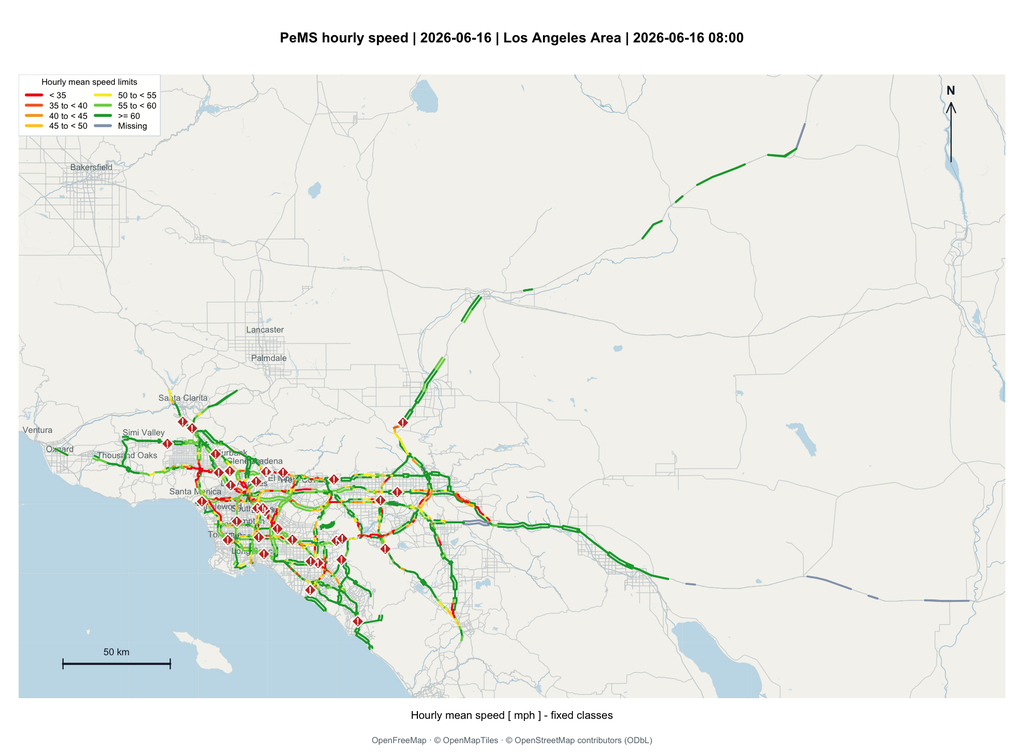

Los Angeles Area freeway speed and CHP starts in the selected hour.

```r
plot_time <- params$plot_time
regions <- c("Los Angeles Area", "San Francisco Bay Area")
la_map <- traffic_speed_map(
  frames_path, time_label = plot_time, region = regions[1L], basemap = basemap,
  full_extent = TRUE, padding = 0.04
)
```

### 4.3 San Francisco Bay Area

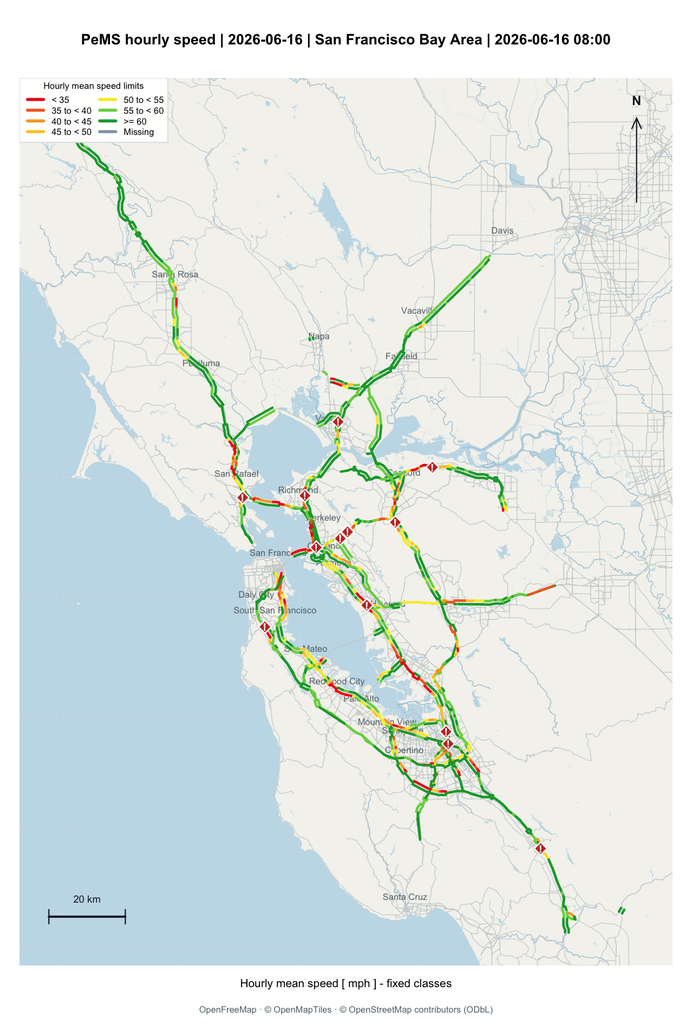

San Francisco Bay Area freeway speed and CHP starts in the selected hour.

```r
bay_map <- traffic_speed_map(
  frames_path, time_label = plot_time, region = regions[2L], basemap = basemap,
  full_extent = TRUE, padding = 0.04
)
```

## 5 Results

The curves show mean freeway hourly speed for the two regions over the full day. Each hourly mean uses the available road values in that region. The dashed lines mark the hour shown on both maps.

### 5.1 Los Angeles Area

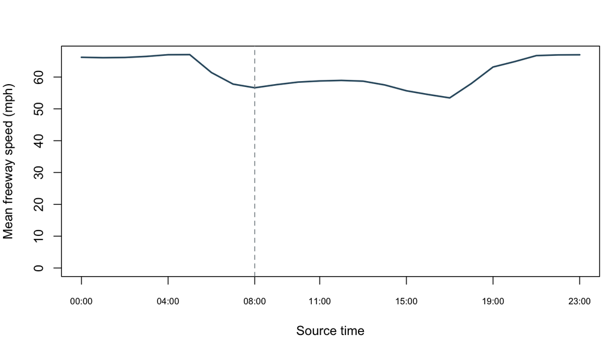

```r
la_trend <- traffic_trend(frames, region = regions[1L])
plot(la_trend, metric = "mean", index = la_map$index,
     ylab = "Mean freeway speed (mph)")
```

### 5.2 San Francisco Bay Area

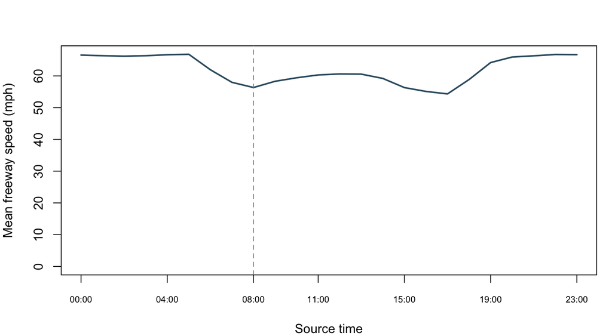

```r
bay_trend <- traffic_trend(frames, region = regions[2L])
plot(bay_trend, metric = "mean", index = bay_map$index,
     ylab = "Mean freeway speed (mph)")
```

## 6 Export the results

Preparation saves its working files in a temporary directory. The draw calls use the current R graphics device. When running the blocks with `Rscript` and no device open, R can create `Rplots.pdf` in the working directory. To regenerate the report HTML and keep the selected maps and complete drawing data, run this command from the example directory:

```bash
Rscript run.R 08:00 --offline --export
```

Replace `08:00` with another prepared frame start to draw that frame. The default destination is a new `output/` directory. To use a different new directory, add `--output-dir NEW_DIRECTORY`.

The command saves the selected maps at `output/maps/pems-speed-los-angeles.png` and `output/maps/pems-speed-bay-area.png`. `output/prepared-data/speed-frames.rds` contains all prepared frames and can be passed to the same plotting function to draw another frame. The directory also contains `source.rds` and `input.rds`, which record intermediate preparation steps.